# The (uneven) rise of personality politics in the media

A large language model approach to complex content annotation  
Work in progress [pre-analysis]

Johannes B. Gruber; Ana Ines Langer (U Glasgow); Mariken van der Velden (VU Amsterdam)

2026-04-24

# Personality politics

## What is personality politics?

> Personality politics describes a shift toward greater emphasis on the individual personalities of politicians in the relationships among media, voters, and political parties.

## How has it been studied?

- Widely studied, but few works take a **longitudinal or comparative** approach – even fewer do both
- Most studies rely on **small samples** and **manual content analysis** → inconsistent methodologies and mixed findings
- Some report **increases** in personality coverage; others find **little change** (Boumans et al. 2013; Langer 2007, 2011; Costa Lobo 2018)
- Limited understanding of **what explains** trends and how they **vary across countries**

## RQs

- **RQ1**: Is there evidence of a positive trend in personality politics in news coverage over time or does the level of personality politics coverage fluctuate?
- **RQ2**: Do we observe similar trends in UK, US and NL politics?
- **RQ3**: Is there a shift in which aspects of politicians’ personalities are covered over time?
- **RQ4**: Which factors help to explain variation over time and across cases?

# Data

## Media Data

[output not shown]

- All left-leaning broadsheets with **long-term archival availability**
- Search via **leader names** (+ variations, e.g. Mrs Thatcher, Maggie, Lady Thatcher, PM Thatcher)
- Covers both **electoral and routine** periods

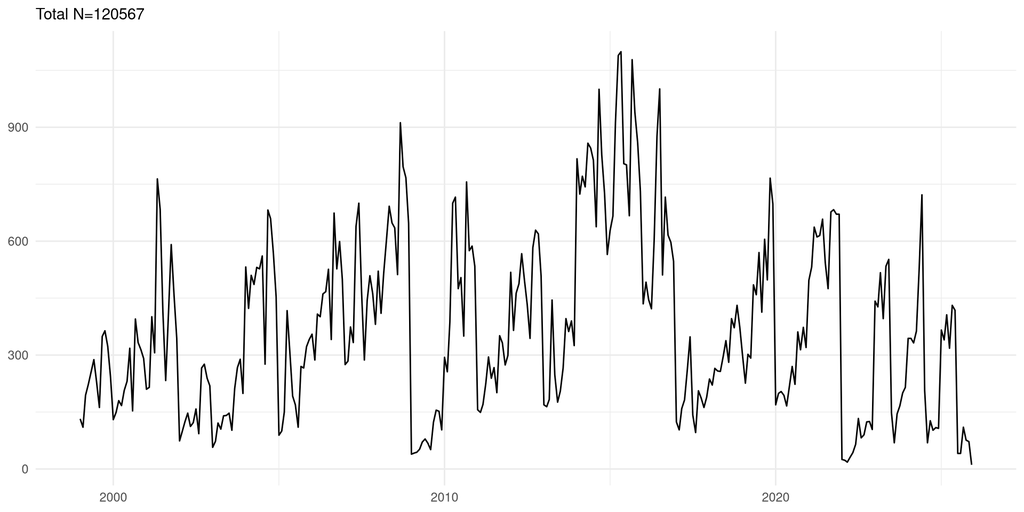

Articles in sample over time

## Independen Variabls

- popularity (measured by electoral results and public opinion surveys)
- variables related to the actor (party, ideology, incumbency status, gender)
- context (unemployment, immigration)

# Methods

## Why LLMs?

Personality politics is a **complex concept** – not just word choice, but:

- *Who* is mentioned (which actor)
- *In what role* (politician, private person, party leader…)
- *Which personality dimension* (character, leadership style, private life…)

Traditional methods (dictionaries, topic models) struggle with this level of nuance.

LLMs enable:

- **Large-scale** annotation at a fraction of the cost of manual coding
- Better fit between concept and measurement (Gruber & Votta 2025; Balluff et al. 2026)

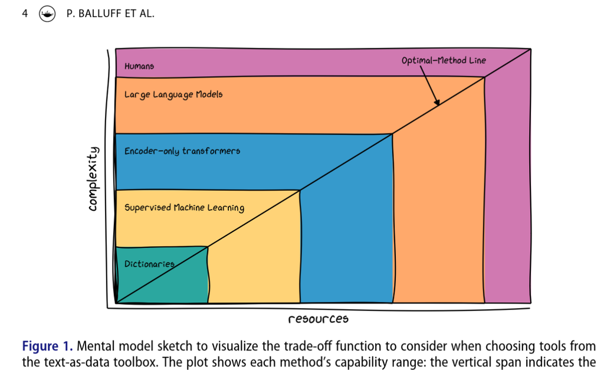

From Balluff et al. 2026

## Model and Framework

- `gpt-oss:120b` (128K context window)
- Through Ollama and rollama (Gruber & Weber 2024)
- Using structured output matching schema

[figure not shown]

[figure not shown]

## Prompt

[output not shown]

[output cut: 372 more lines]

[output not shown]

## Two tasks

1. Article Focus Classification

[output not shown]

2. Personality Politics Dimensions

[output not shown]

## Examples and Structured Output

[output not shown]

# Validation

## Validation: Article Focus

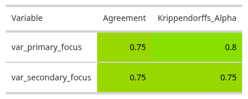

Intercoder Reliability (3 coder)

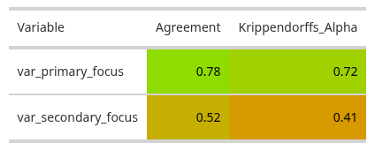

Intercoder Reliability (3 coder + Model)

## Validation: Personality Politics Dimensions

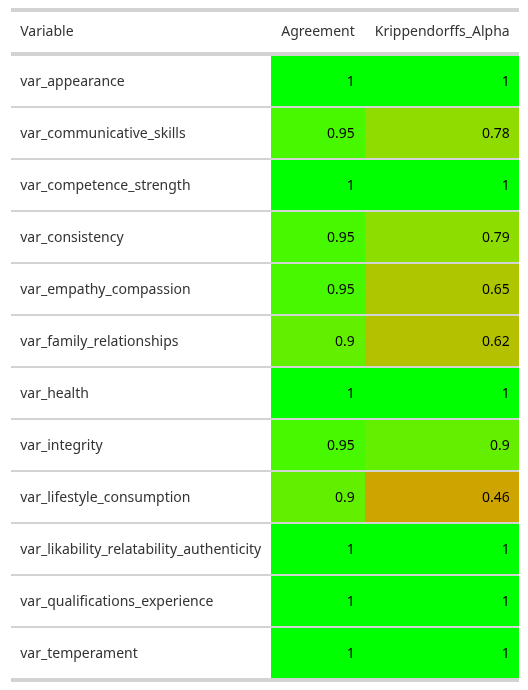

Intercoder Reliability (3 coder)

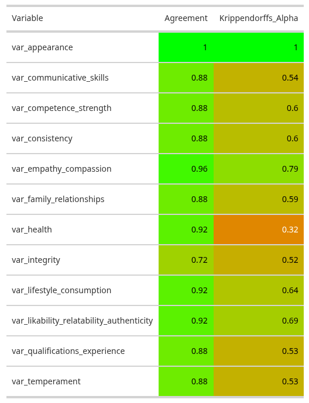

Intercoder Reliability (3 coder + Model)

# Next Steps

- Finish validation:
  - Fix disagreement
  - how robust is annotation between runs & models
- Scale up annotation to full corpus
- Time series analysis to identify trends (RQ1–RQ3)
- Multilevel modelling: observations nested within countries (RQ4)
- Explanatory variables: electoral results, public opinion surveys, party, ideology, incumbency, gender

[figure not shown]

# Thank you for your attention!